# Data Visualization: `ggplot` part 2

## Learning Goals

*At the end of this exercise, you will be able to:*  
1. Build stacked bar plots of categorical variables.  
2. Build side-by-side barplots using `position= "dodge"`.  
3. Build histograms and density plots.  
4. Create new categories with `case_when()`.

## Group project

As you prepare to meet in groups today and think about the kind of data and project you want to pursue, consider these suggestions.  
1. You are free to use whatever data you want, but it should be reasonably sized and not too messy.  
2. It should have a mix of categorical and continuous variables.  
3. Know your audience- don’t be too hip for the room.  
4. Be polite.

## Meet your group

Please take 10 minutes to meet your partner(s) for the class project. Here is what you need to do:  
1. Introduce yourself and exchange contact information.  
2. Think about the kind of data and questions you would like to pursue.  
3. Browse around on the internet a little to see what is available- are your questions reasonable?  
4. Make a plan to collect at least two different sources of data to compare on Thursday.

## Resources

- [ggplot2 cheatsheet](https://www.rstudio.com/wp-content/uploads/2015/03/ggplot2-cheatsheet.pdf)

## Load the libraries

```r
library(tidyverse)
library(here)
library(janitor)
library(palmerpenguins)
```

```r
options(scipen=999) #cancels the use of scientific notation for the session
```

## Data

**Database of vertebrate home range sizes.**  
Reference: Tamburello N, Cote IM, Dulvy NK (2015) Energy and the scaling of animal space use. The American Naturalist 186(2):196-211. http://dx.doi.org/10.1086/682070.  
Data: http://datadryad.org/resource/doi:10.5061/dryad.q5j65/1

```r
homerange <- read_csv(here("lab10", "data", "Tamburelloetal_HomeRangeDatabase.csv"), na = c("", "NA", "\\"))
```

## A few more useful aesthetics

There are many options to create nice plots in ggplot. One useful trick is to store the plot as a new object and then experiment with geom’s and aesthetics.

```r
p <- homerange %>%
  ggplot(aes(x= log10.mass, y= log10.hra))
```

Play with point size.

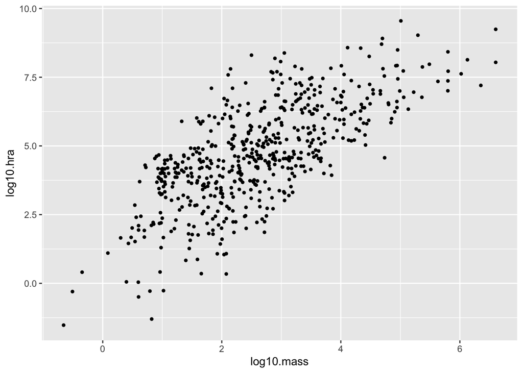

```r
p +geom_point(size=1)
```

Map shapes to another categorical variable.

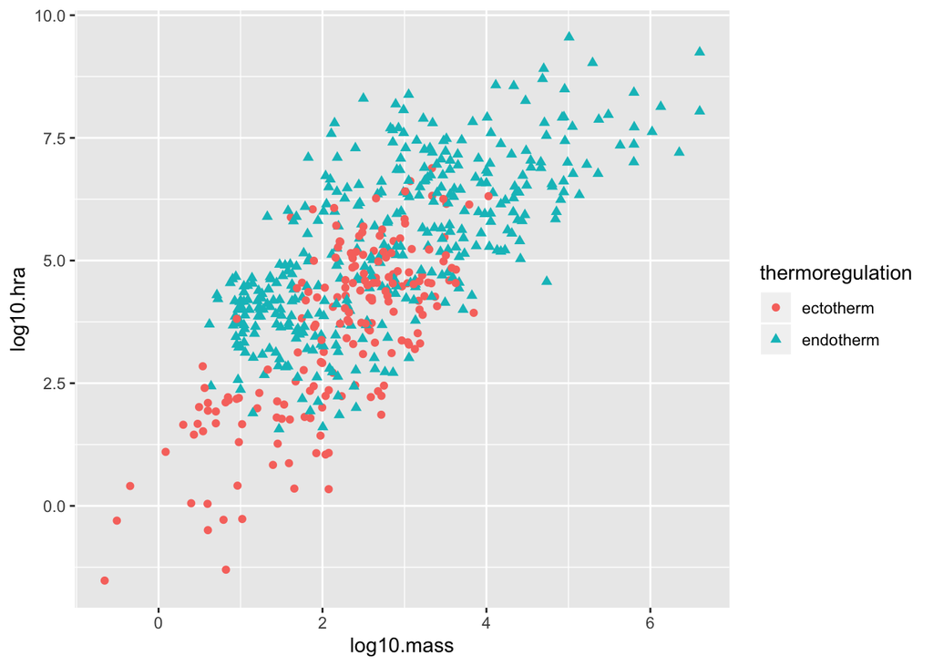

```r
p+geom_point(aes(shape=thermoregulation, color=thermoregulation), size=1.75)
```

## Barplots and multiple variables

At this point you should be comfortable building bar plots that shows counts of observations using `geom_bar()`. Last time we explored the `fill` option in box plots as a way to bring color to the plot; i.e. we filled by the same variable that we were plotting. What happens when we fill by a different categorical variable?

Let’s start by counting how many observations we have in each taxonomic group.

```r
homerange %>% count(taxon)
```

```
## # A tibble: 9 x 2
##   taxon             n
##   <chr>         <int>
## 1 birds           140
## 2 lake fishes       9
## 3 lizards          11
## 4 mammals         238
## 5 marine fishes    90
## 6 river fishes     14
## 7 snakes           41
## 8 tortoises        12
## 9 turtles          14
```

Now let’s make a bar plot of these data.

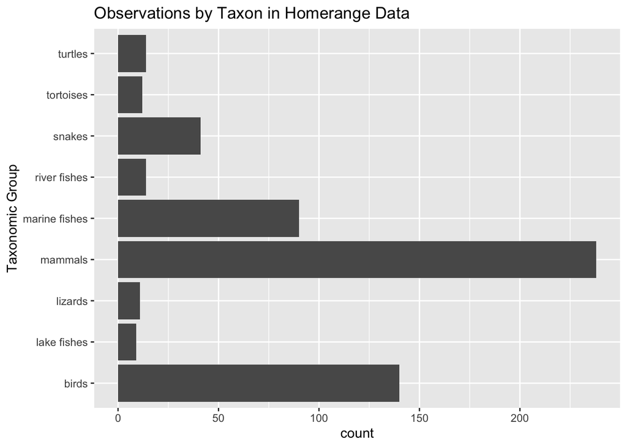

```r
homerange %>%
  ggplot(aes(x = taxon)) + geom_bar() +
  coord_flip() +
  labs(title = "Observations by Taxon in Homerange Data",
       x = "Taxonomic Group")
```

By specifying `fill=trophic.guild` we build a stacked bar plot that shows the proportion of a given taxonomic group that is an herbivore or carnivore.

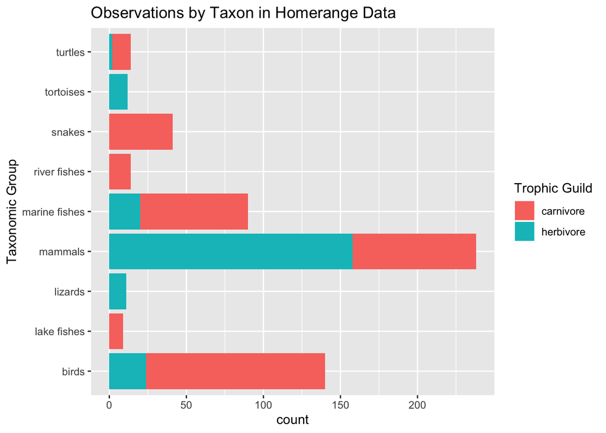

```r
homerange %>%
  ggplot(aes(x = taxon, fill = trophic.guild)) + geom_bar() +
  coord_flip() +
  labs(title = "Observations by Taxon in Homerange Data",
       x = "Taxonomic Group",
       fill = "Trophic Guild")
```

We can also have counts of each trophic guild within taxonomic group shown side-by-side by specifying `position="dodge"`.

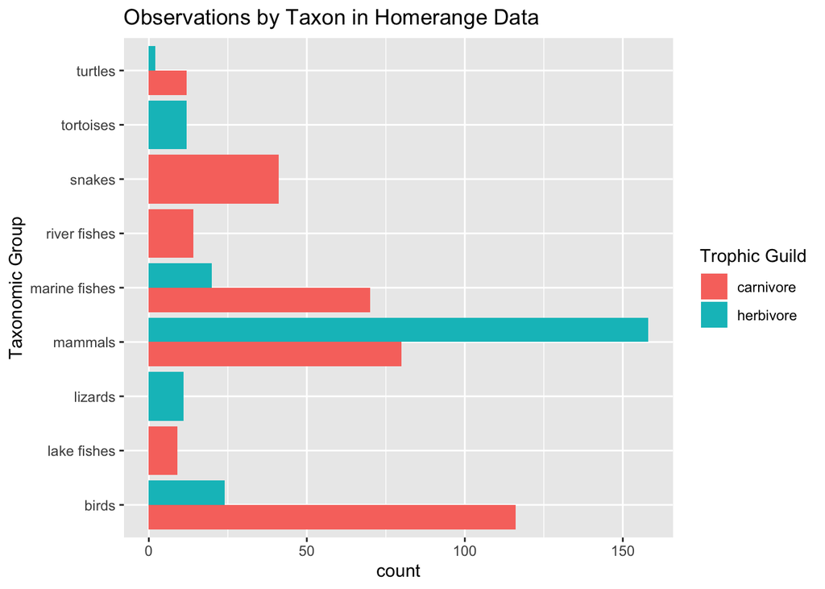

```r
homerange %>%
  ggplot(aes(x = taxon, fill = trophic.guild)) + geom_bar(position = "dodge") +
  coord_flip() +
  labs(title = "Observations by Taxon in Homerange Data",
       x = "Taxonomic Group",
       fill = "Trophic Guild")
```

Here is the same plot oriented vertically.

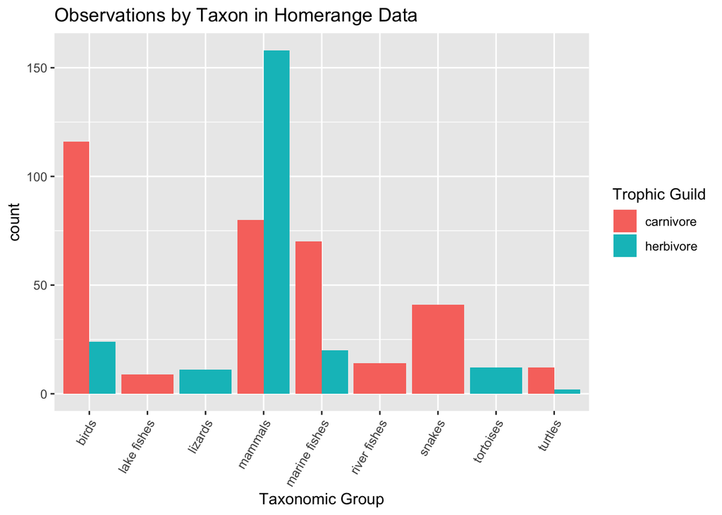

```r
homerange %>%
  ggplot(aes(x = taxon, fill = trophic.guild)) +
  geom_bar(position = "dodge") +
  theme(axis.text.x = element_text(angle = 60, hjust = 1)) +
  labs(title = "Observations by Taxon in Homerange Data",
       x = "Taxonomic Group",
       fill= "Trophic Guild")
```

We can also scale all bars to a percentage (or proportion).

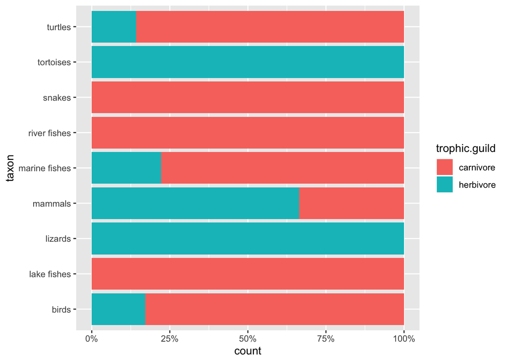

```r
homerange %>%
  ggplot(aes(x = taxon, fill = trophic.guild))+
  geom_bar(position = position_fill())+
  scale_y_continuous(labels = scales::percent)+
  coord_flip()
```

## Practice

For this practice, let’s use the [palmerpenguins](https://allisonhorst.github.io/palmerpenguins/articles/intro.html) data.

1. Make a bar plot that shows counts of individuals by island. Fill by species, and try both a stacked bar plot and `position="dodge"`.

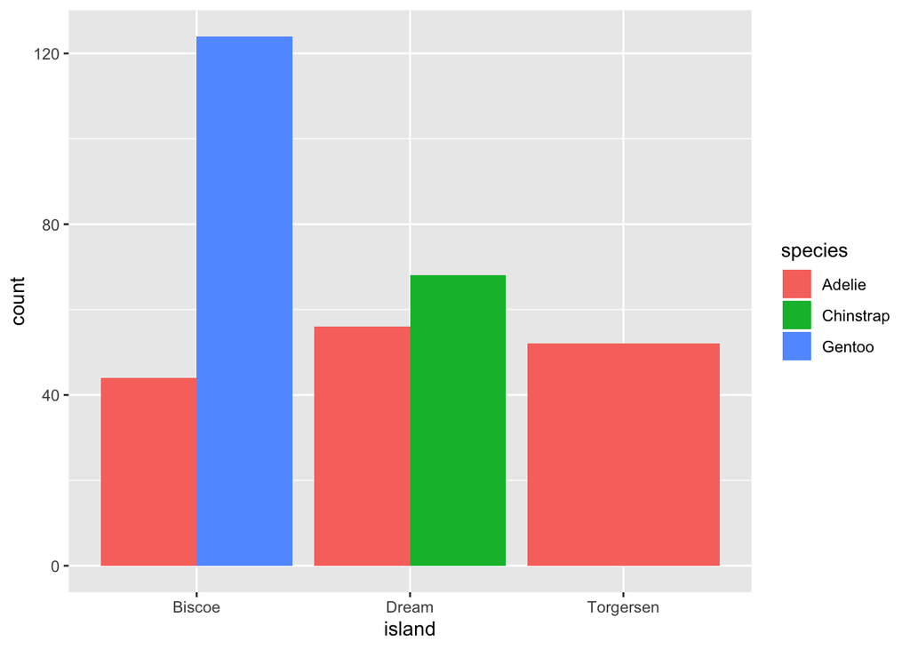

```r
penguins %>%
  ggplot(aes(x=island,fill=species)) + geom_bar(position="dodge")
```

2. What are the number of individuals separated by sex on each island?

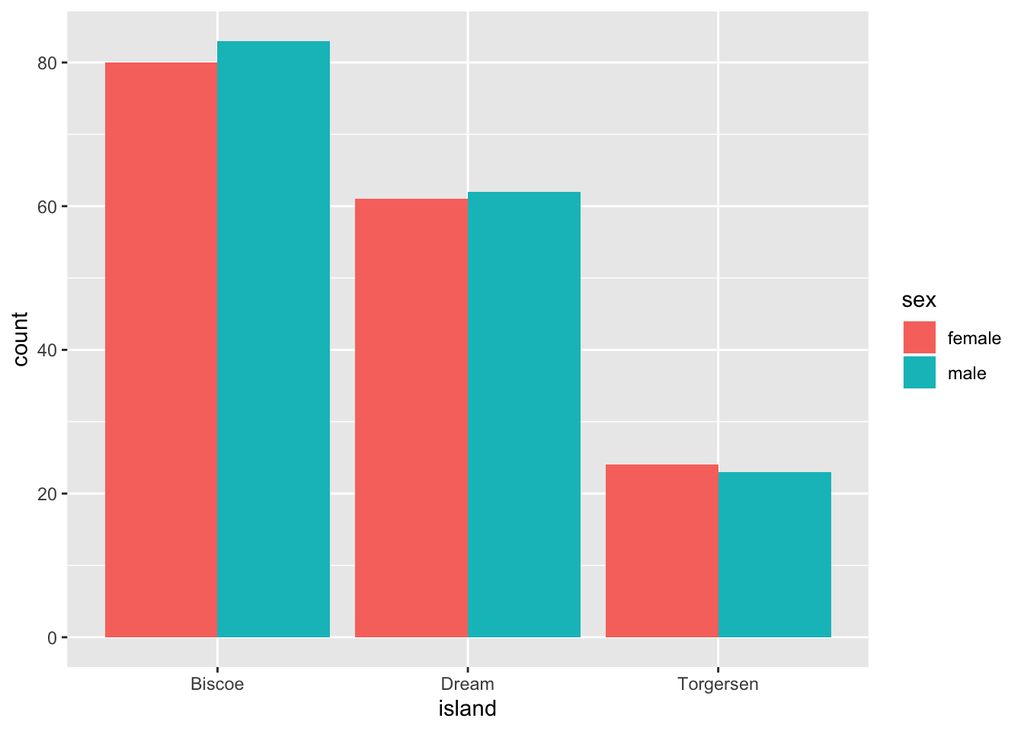

```r
penguins %>%
  filter(sex!="NA") %>%
  ggplot(aes(x=island,fill=sex)) + geom_bar(position="dodge")
```

## Using `group`

In addition to `fill`, `group` is an aesthetic that accomplishes the same function but does not add color.

Here is a box plot that shows `log10.mass` by taxonomic `class.`

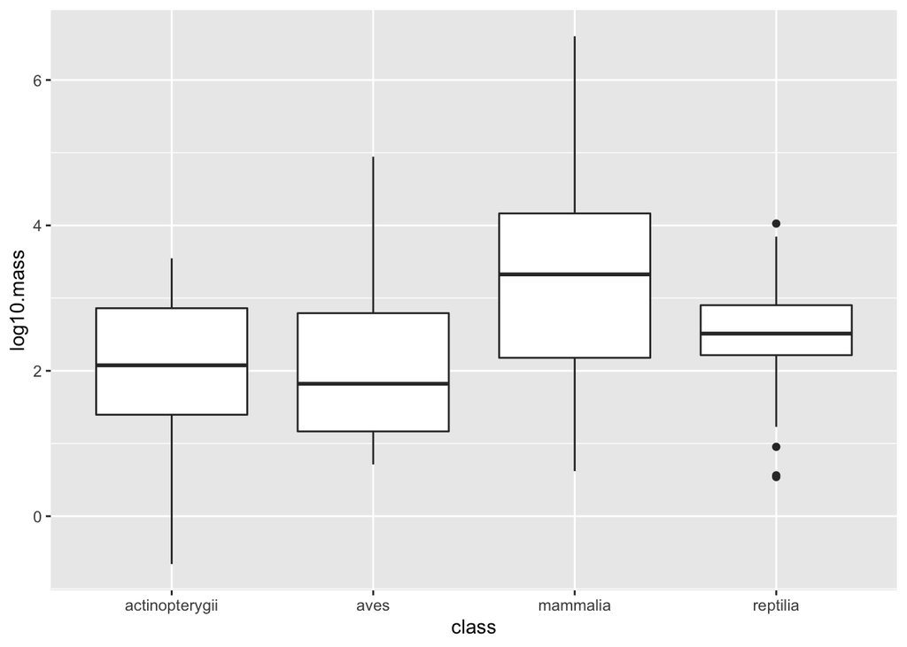

```r
homerange %>%
  ggplot(aes(x = class, y = log10.mass)) +
  geom_boxplot()
```

I use `group` to make individual box plots for each taxon.

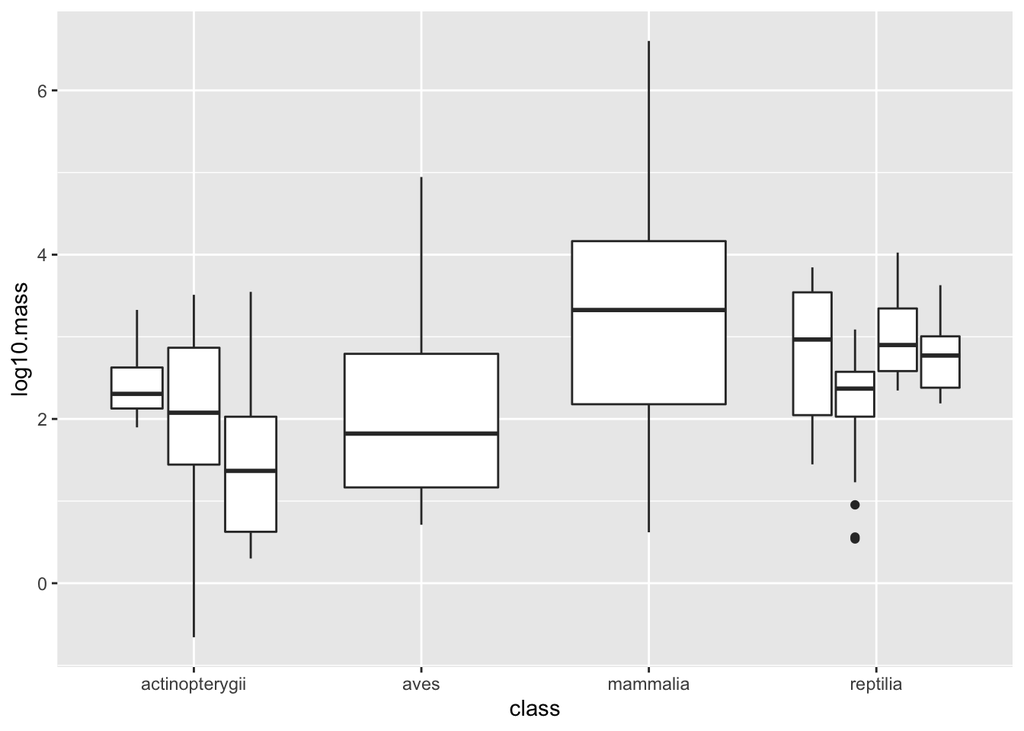

```r
homerange %>%
  ggplot(aes(x = class, y = log10.mass, group = taxon)) +
  geom_boxplot()
```

I can also use `fill` to associate the different taxa with a color coded key.

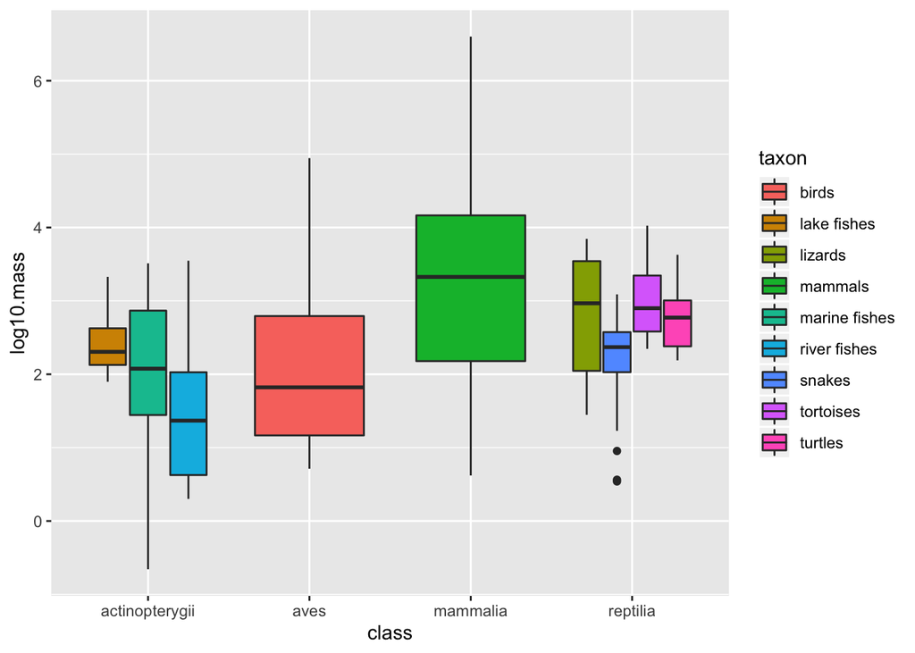

```r
homerange %>%
  ggplot(aes(x = class, y = log10.mass, fill = taxon)) +
  geom_boxplot()
```

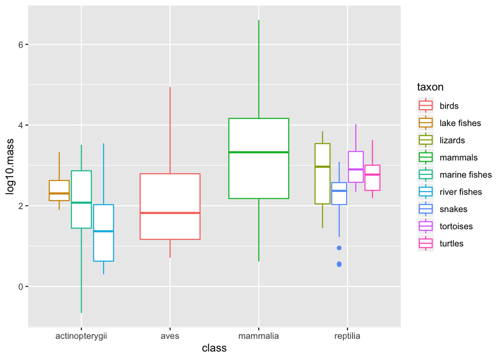

```r
homerange %>%
  ggplot(aes(x = class, y = log10.mass, color = taxon)) +
  geom_boxplot()
```

## That’s it, let’s take a break!

–>[Home](https://jmledford3115.github.io/datascibiol/)